# Projeto Especial 2

Jefferson Alves

27 de fevereiro de 2019

## Projeto Especial 2 - Prevendo Demanda de Estoque com Base em Vendas

Este projeto tem como objetivo desenvolver um modelo de aprendizado de máquina para prever com precisão a demanda de estoque com base nos dados históricos de vendas de um grande grupo empresarial denominado Grupo Bimbo (https://www.grupobimbo.com).

Para maiores detalhes sobre os dados utlilizados neste projeto, consulte o link https://www.kaggle.com/c/grupo-bimbo-inventory-demand.

Todo o projeto será descrito de acordo com suas etapas.

## Etapa 1 - Coleta dos Dados

Devido a restrições de memória, optou-se por usar parcialmente os dados dos arquivos ‘train.csv’ e ‘test.csv’.

Logo abaixo está a descrição dos campos, onde cada registro representa um consumode produto por um cliente num canal de vendas num dado momento de tempo e proveniente de uma entrega originada de um depósito.

- Semana — Week number (From Thursday to Wednesday)
- Agencia_ID — Sales Depot ID
- Canal_ID — Sales Channel ID
- Ruta_SAK — Route ID (Several routes = Sales Depot)
- Cliente_ID — Client ID
- NombreCliente — Client name
- Producto_ID — Product ID
- NombreProducto — Product Name
- Venta_uni_hoy — Sales unit this week (integer)
- Venta_hoy — Sales this week (unit: pesos)
- Dev_uni_proxima — Returns unit next week (integer)
- Dev_proxima — Returns next week (unit: pesos)
- Demanda_uni_equil — Adjusted Demand (integer) (This is the target you will predict)
- foram preservados os nomes e descrições originais do dataset

Estrutura do dataset de treino:

```r
glimpse(df_train)
```

```
## Observations: 500,000
## Variables: 11
## $ Semana            <int> 3, 3, 3, 3, 3, 3, 3, 3, 3, 3, 3, 3, 3, 3, 3,...
## $ Agencia_ID        <int> 1110, 1110, 1110, 1110, 1110, 1110, 1110, 11...
## $ Canal_ID          <int> 7, 7, 7, 7, 7, 7, 7, 7, 7, 7, 7, 7, 7, 7, 7,...
## $ Ruta_SAK          <int> 3301, 3301, 3301, 3301, 3301, 3301, 3301, 33...
## $ Cliente_ID        <int> 15766, 15766, 15766, 15766, 15766, 15766, 15...
## $ Producto_ID       <int> 1212, 1216, 1238, 1240, 1242, 1250, 1309, 38...
## $ Venta_uni_hoy     <int> 3, 4, 4, 4, 3, 5, 3, 6, 4, 6, 8, 4, 12, 7, 1...
## $ Venta_hoy         <dbl> 25.14, 33.52, 39.32, 33.52, 22.92, 38.20, 20...
## $ Dev_uni_proxima   <int> 0, 0, 0, 0, 0, 0, 0, 0, 0, 0, 0, 0, 0, 0, 0,...
## $ Dev_proxima       <dbl> 0, 0, 0, 0, 0, 0, 0, 0, 0, 0, 0, 0, 0, 0, 0,...
## $ Demanda_uni_equil <int> 3, 4, 4, 4, 3, 5, 3, 6, 4, 6, 8, 4, 12, 7, 1...
```

Estrutura do dataset de teste:

```r
glimpse(df_test)
```

```
## Observations: 100,000
## Variables: 7
## $ id          <int> 0, 1, 2, 3, 4, 5, 6, 7, 8, 9, 10, 11, 12, 13, 14, ...
## $ Semana      <int> 11, 11, 10, 11, 11, 11, 11, 10, 10, 11, 11, 10, 11...
## $ Agencia_ID  <int> 4037, 2237, 2045, 1227, 1219, 1146, 2057, 1612, 13...
## $ Canal_ID    <int> 1, 1, 1, 1, 1, 4, 1, 1, 1, 1, 1, 1, 1, 1, 1, 1, 1,...
## $ Ruta_SAK    <int> 2209, 1226, 2831, 4448, 1130, 6601, 4507, 2837, 12...
## $ Cliente_ID  <int> 4639078, 4705135, 4549769, 4717855, 966351, 174141...
## $ Producto_ID <int> 35305, 1238, 32940, 43066, 1277, 972, 1232, 35305,...
```

## Etapa 2 - Exploração dos Dados

Após verificar a existência ou não de “missing values” em ambos os datasets, foi realizada uma análise da distribuição das demais variáveis do dataset de treino.

```r
# verificando "missing values" nos dataset´s de treino e teste
any(is.na(df_train))
```

```
## [1] FALSE
```

```r
any(is.na(df_test))
```

```
## [1] FALSE
```

Foi realizada uma análise gráfica de correlação entre algumas variáveis de negócio consideradas mais relevantes num primeiro momento, permitindo identificar visualmente um indício de possível relacionamento entre elas.

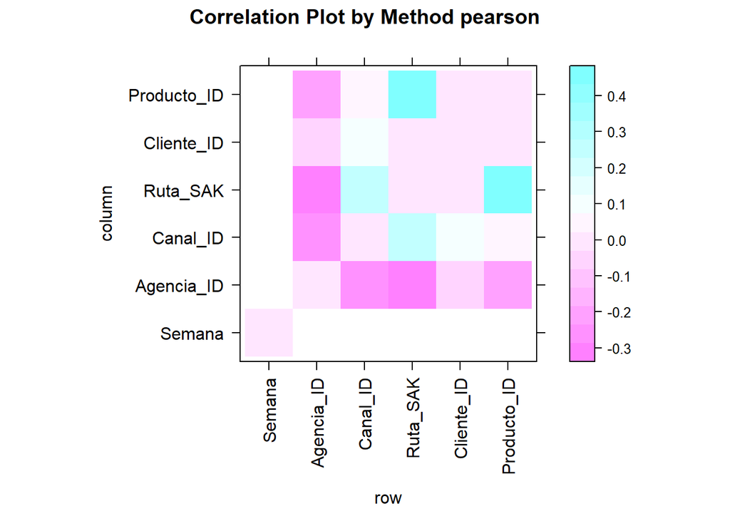

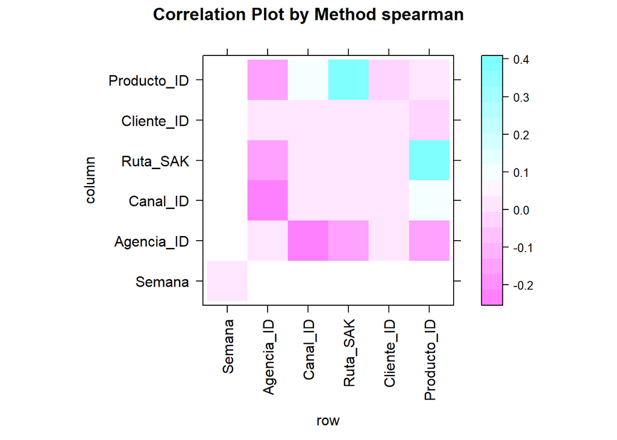

Abaixo estão alguns gráficos de distribuição das variáveis de negócio, ratificando a percepção de tratamento de algumas variáveis e exclusão de outras além da necessidade de normalização dados.

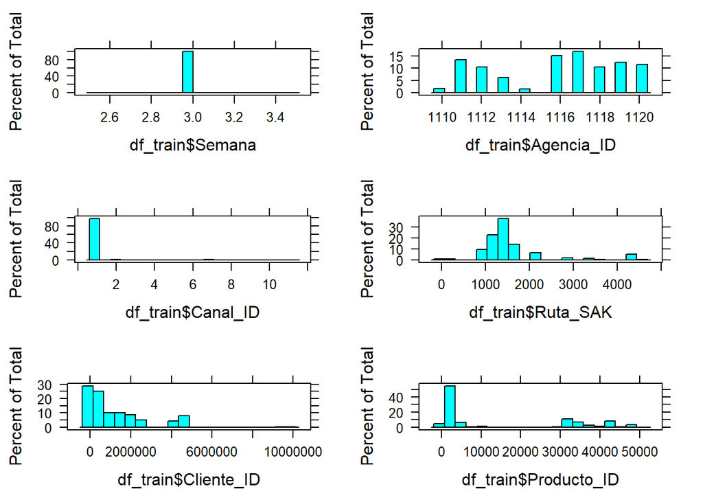

A partir das análises abaixo da variável “Demanda_uni_equil”, identificou-se a presença de outliers e uma grande concentração de valores numa determinada faixa, reforçando a necessidade de normalização dos dados.

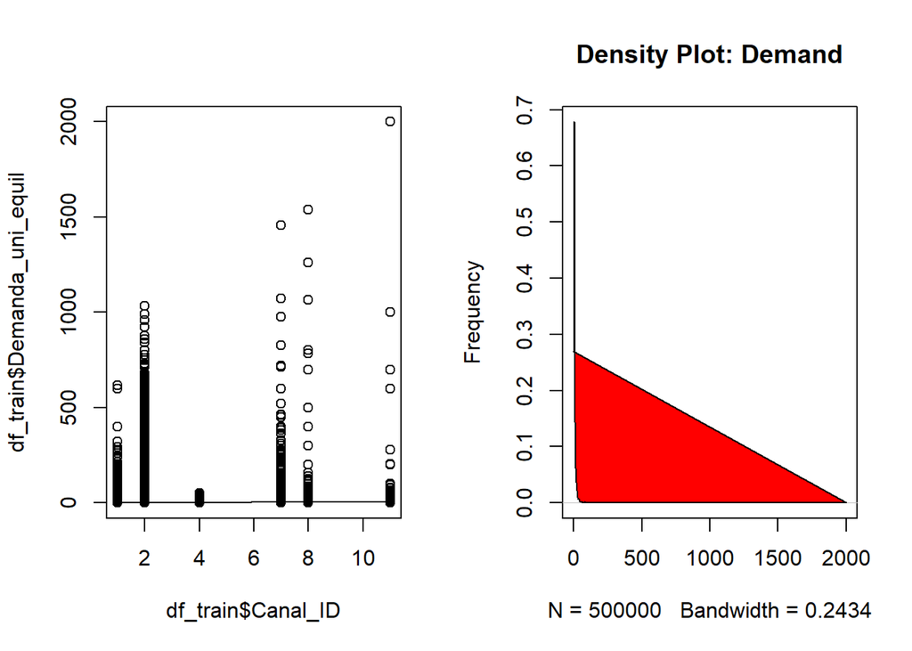

Foram observadas poucas ocorrências de valores únicos para determinadas varáveis, reforçando a percepção de tratamento de algumas variáveis e exclusão de outras.

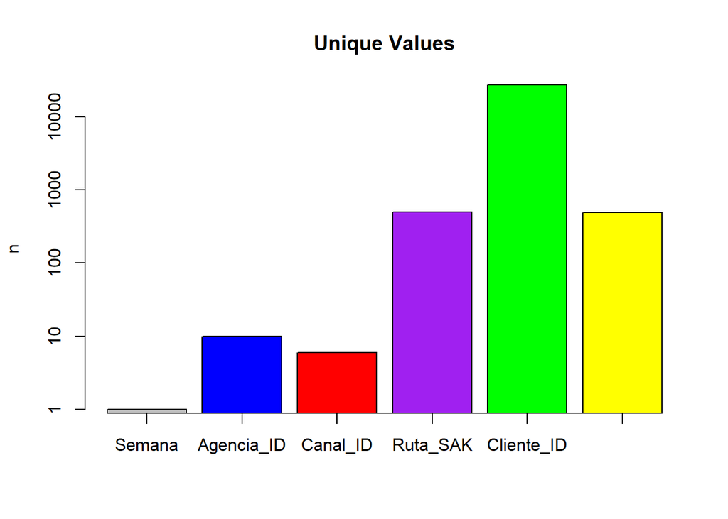

Considerando o objetivo principal que é prever a demanda dos produtos por depósito e a análise de correlação entre as variáveis, optou-se por gerar um dataset contendo apenas algumas variáveis.

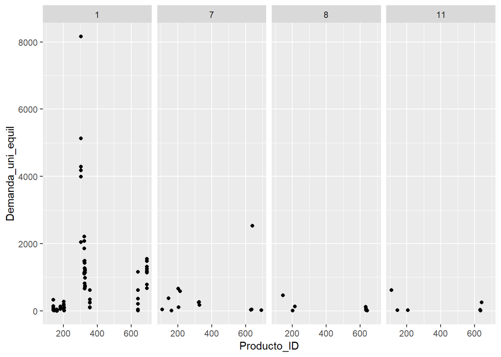

## Etapa 3 - Tratamento dos Dados

Os datasets de treino e teste foram readequados de forma a ficarem com a estrutura semelhante.

Dataset de treino:

```r
glimpse(df_train)
```

```
## Observations: 500,000
## Variables: 7
## $ Semana            <int> 3, 3, 3, 3, 3, 3, 3, 3, 3, 3, 3, 3, 3, 3, 3,...
## $ Agencia_ID        <int> 1110, 1110, 1110, 1110, 1110, 1110, 1110, 11...
## $ Canal_ID          <int> 7, 7, 7, 7, 7, 7, 7, 7, 7, 7, 7, 7, 7, 7, 7,...
## $ Ruta_SAK          <int> 3301, 3301, 3301, 3301, 3301, 3301, 3301, 33...
## $ Cliente_ID        <int> 15766, 15766, 15766, 15766, 15766, 15766, 15...
## $ Producto_ID       <int> 1212, 1216, 1238, 1240, 1242, 1250, 1309, 38...
## $ Demanda_uni_equil <dbl> 3, 4, 4, 4, 3, 5, 3, 6, 4, 6, 8, 4, 12, 7, 1...
```

Dataset de teste:

```r
glimpse(df_test)
```

```
## Observations: 100,000
## Variables: 7
## $ Semana            <int> 11, 11, 10, 11, 11, 11, 11, 10, 10, 11, 11, ...
## $ Agencia_ID        <int> 4037, 2237, 2045, 1227, 1219, 1146, 2057, 16...
## $ Canal_ID          <int> 1, 1, 1, 1, 1, 4, 1, 1, 1, 1, 1, 1, 1, 1, 1,...
## $ Ruta_SAK          <int> 2209, 1226, 2831, 4448, 1130, 6601, 4507, 28...
## $ Cliente_ID        <int> 4639078, 4705135, 4549769, 4717855, 966351, ...
## $ Producto_ID       <int> 35305, 1238, 32940, 43066, 1277, 972, 1232, ...
## $ Demanda_uni_equil <dbl> 0, 0, 0, 0, 0, 0, 0, 0, 0, 0, 0, 0, 0, 0, 0,...
```

```
## [1] "Foram identificados 517 produtos nos dados de teste e que estão fora dos dados de treino."
```

Logo abaixo está uma visualização dos valores únicos para os dados de teste que deverão ser inseridos no dataset de treino.

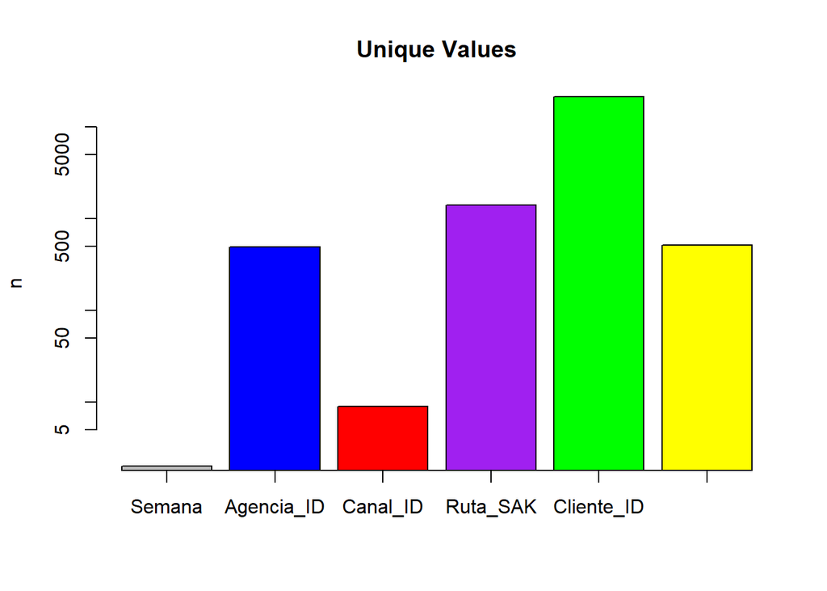

Tanto os dados de treino quanto de teste precisarão ser normalizados antes da fase de treinamento do modelo preditivo, conforme constatado abaixo.

Dataset de treino antes da normalização:

```
##      Semana         Agencia_ID       Canal_ID
##  Min.   : 3.000   Min.   : 1110   Min.   : 1.000
##  1st Qu.: 3.000   1st Qu.: 1113   1st Qu.: 1.000
##  Median : 3.000   Median : 1117   Median : 1.000
##  Mean   : 3.321   Mean   : 1186   Mean   : 1.134
##  3rd Qu.: 3.000   3rd Qu.: 1119   3rd Qu.: 1.000
##  Max.   :11.000   Max.   :25759   Max.   :11.000
```

Dataset de treino após normalização:

```
##      Semana          Agencia_ID           Canal_ID
##  Min.   :0.00000   Min.   :0.0000000   Min.   :0.0000
##  1st Qu.:0.00000   1st Qu.:0.0001217   1st Qu.:0.0000
##  Median :0.00000   Median :0.0002840   Median :0.0000
##  Mean   :0.04009   Mean   :0.0030917   Mean   :0.0134
##  3rd Qu.:0.00000   3rd Qu.:0.0003651   3rd Qu.:0.0000
##  Max.   :1.00000   Max.   :1.0000000   Max.   :1.0000
```

Dataset de teste antes da normalização:

```
##      Semana        Agencia_ID       Canal_ID
##  Min.   :10.00   Min.   : 1110   Min.   : 1.000
##  1st Qu.:10.00   1st Qu.: 1311   1st Qu.: 1.000
##  Median :10.00   Median : 1613   Median : 1.000
##  Mean   :10.49   Mean   : 2522   Mean   : 1.402
##  3rd Qu.:11.00   3rd Qu.: 2034   3rd Qu.: 1.000
##  Max.   :11.00   Max.   :25759   Max.   :11.000
```

[output not shown]

## Etapa 4 - Treinamento e Otimização do Modelo

Após o tratamento e normalização dos dados parciais contidos nos dataset´s de treino e teste, será realizado o processo de treinamento do modelo preditivo via técnica de Regressão Linear.

No primeiro modelo, optou-se por manter todas as variáveis de negócio, apesar dos indícios de correlação de algumas, de forma a ter um parâmetro inicial de comparativo de performance do modelo.

```r
# Criando o modelo de regressão - v01
formula.init.v01 <- "Demanda_uni_equil ~ ."
formula.init.v01 <- as.formula(formula.init.v01)
lr.model_v01 <- lm(formula = formula.init.v01, data = df_train_norm)

# Visualizando os detalhes do modelo
summ(lr.model_v01, n.sd = 2, robust = "HC1")
```

| Observations | 522291 |
| --- | --- |
| Dependent variable | Demanda_uni_equil |
| Type | OLS linear regression |

| F(6,522284) | 4576.33 |
| --- | --- |
| R² | 0.05 |
| Adj. R² | 0.05 |

|  | Est. | S.E. | t val. | p |
| --- | --- | --- | --- | --- |
| (Intercept) | 10.05 | 0.10 | 104.14 | 0.00 |
| Semana | -8.45 | 0.07 | -114.38 | 0.00 |
| Agencia_ID | -0.57 | 0.19 | -3.04 | 0.00 |
| Canal_ID | 29.61 | 1.07 | 27.64 | 0.00 |
| Ruta_SAK | -31.95 | 0.69 | -46.41 | 0.00 |
| Cliente_ID | -3.92 | 0.16 | -25.14 | 0.00 |
| Producto_ID | 7.78 | 0.14 | 54.43 | 0.00 |

Standard errors: Robust, type = HC1

```r
# Criando o modelo de regressão - v02
formula.init.v02 <- "Demanda_uni_equil ~ Semana + Cliente_ID + Canal_ID + Ruta_SAK + Producto_ID"
formula.init.v02 <- as.formula(formula.init.v02)
lr.model_v02 <- lm(formula = formula.init.v02, data = df_train_norm)
```

```r
# Criando o modelo de regressão - v03
formula.init.v03 <- "Demanda_uni_equil ~ Cliente_ID + Ruta_SAK + Producto_ID"
formula.init.v03 <- as.formula(formula.init.v03)
lr.model_v03 <- lm(formula = formula.init.v03, data = df_train_norm)
```

```r
# Criando o modelo de regressão - v04
formula.init.v04 <- "Demanda_uni_equil ~ Canal_ID + Ruta_SAK + Producto_ID"
formula.init.v04 <- as.formula(formula.init.v04)
lr.model_v04 <- lm(formula = formula.init.v04, data = df_train_norm)
```

## Etapa 5 - Avaliação dos Resultados da Otimização do Modelo

O gráfico abaixo mostra o desvio das variáveis contidas em cada um dos modelos gerados, possibilitando identificar visualmente qual modelo pode escolhido para ser usado na predição.

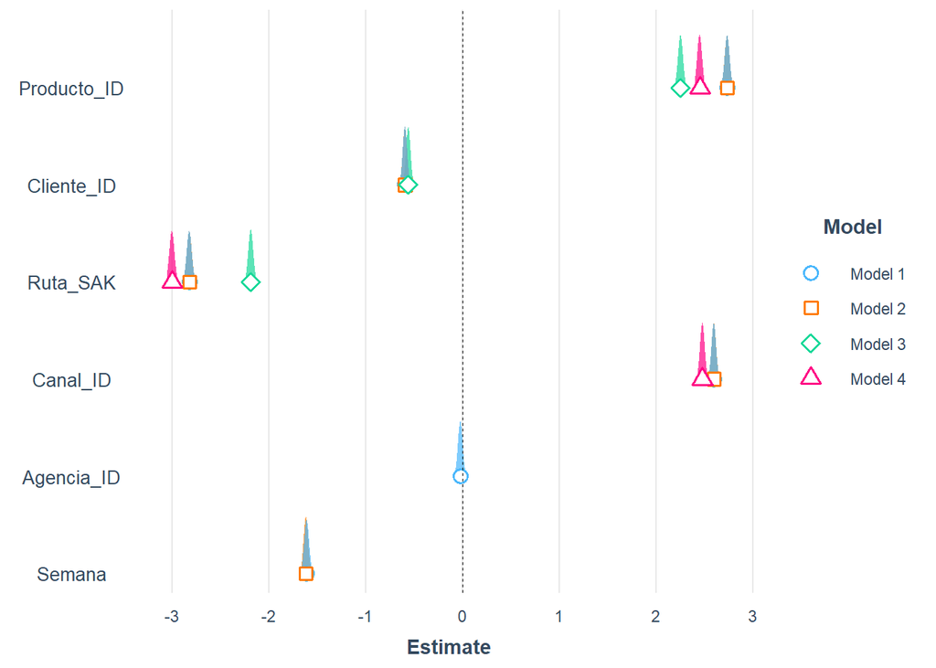

|  | Model 1 | Model 2 | Model 3 | Model 4 |
| --- | --- | --- | --- | --- |
| (Intercept) | 6.58 *** | 6.58 *** | 6.58 *** | 6.58 *** |
|  | (288.44) | (288.44) | (284.17) | (286.88) |
| Semana | -1.61 *** | -1.62 *** |  |  |
|  | (-64.01) | (-68.28) |  |  |
| Agencia_ID | -0.02 |  |  |  |
|  | (-0.92) |  |  |  |
| Canal_ID | 2.59 *** | 2.59 *** |  | 2.48 *** |
|  | (108.20) | (108.23) |  | (103.07) |
| Ruta_SAK | -2.82 *** | -2.82 *** | -2.18 *** | -3.00 *** |
|  | (-106.70) | (-106.70) | (-85.45) | (-113.39) |
| Cliente_ID | -0.59 *** | -0.59 *** | -0.56 *** |  |
|  | (-25.82) | (-25.83) | (-24.11) |  |
| Producto_ID | 2.73 *** | 2.73 *** | 2.25 *** | 2.45 *** |
|  | (106.77) | (106.77) | (88.05) | (96.41) |
| N | 522291 | 522291 | 522291 | 522291 |
| R2 | 0.05 | 0.05 | 0.02 | 0.04 |
| *** p < 0.001; ** p < 0.01; * p < 0.05. |  |  |  |  |

## Etapa 6 - Execução do Modelo Preditivo e Avaliação dos Resultados

| fit | lwr | upr |
| --- | --- | --- |
| -1.7e+07 | -1.84e+07 | -1.56e+07 |
| -1.74e+07 | -1.88e+07 | -1.6e+07 |
| -1.67e+07 | -1.8e+07 | -1.53e+07 |
| -1.73e+07 | -1.87e+07 | -1.58e+07 |
| -3.59e+06 | -3.88e+06 | -3.3e+06 |
| -6.59e+06 | -7.11e+06 | -6.06e+06 |

```
##       fit                 lwr                 upr
##  Min.   :-43004262   Min.   :-46513481   Min.   :-39495042
##  1st Qu.: -8749088   1st Qu.: -9468177   1st Qu.: -8029871
##  Median : -4378573   Median : -4739674   Median : -4017716
##  Mean   : -6631918   Mean   : -7178269   Mean   : -6085566
##  3rd Qu.: -1240425   3rd Qu.: -1347951   3rd Qu.: -1132192
##  Max.   :   266004   Max.   :   259250   Max.   :   272757
```

```
## [1] "Conforme tabela abaixo, a Taxa de Acerto do Modelo: 2.10%"
```

[interactive table not shown]